# Assignment 4: Building and Evaluating Ensemble Models

Shyni David

2/18/2019

##### Directions

This assignment extends the work you did as part of assignment 3 using the German Credit data set. In that assignment, you built, fine-tuned, and compared the performance of four candidate classification models: a logistic regression model, a regularized linear model using an elasticnet penalty for shrinkage, a classification tree model, and a neural net model. Your primary task in this assignment is to see if you might be able to improve on the work you have done by building and assessing the performance of different ensemble models using the three main techniques/methods for ensembling: bagging, boosting, and stacking.

Set up library

```r
library(caret)
library(glmnet)
#install.packages("caTools")
library(caTools)  ##for ROC
library(tidyverse)
```

#### Load the data

```r
 germancredit = read.table("http://archive.ics.uci.edu/ml/machine-learning-databases/statlog/german/german.data")

colnames(germancredit) <- c("chkactstatus", "duration", "credithistory", "purpose", "amount", "saving", "presentjob", "installmentrate", "sexstatus", "otherdebtor", "resident", "property", "age", "otherinstall", "housing", "ncredits", "job", "npeople", "telephone", "foreign", "response")

germancredit$response = as.factor(germancredit$response) # coded as 1=good_risk, 2=bad_risk

table(germancredit$response)
```

```
##
##   1   2
## 700 300
```

```r
str(germancredit)
```

```
## 'data.frame':    1000 obs. of  21 variables:
##  $ chkactstatus   : Factor w/ 4 levels "A11","A12","A13",..: 1 2 4 1 1 4 4 2 4 2 ...
##  $ duration       : int  6 48 12 42 24 36 24 36 12 30 ...
##  $ credithistory  : Factor w/ 5 levels "A30","A31","A32",..: 5 3 5 3 4 3 3 3 3 5 ...
##  $ purpose        : Factor w/ 10 levels "A40","A41","A410",..: 5 5 8 4 1 8 4 2 5 1 ...
##  $ amount         : int  1169 5951 2096 7882 4870 9055 2835 6948 3059 5234 ...
##  $ saving         : Factor w/ 5 levels "A61","A62","A63",..: 5 1 1 1 1 5 3 1 4 1 ...
##  $ presentjob     : Factor w/ 5 levels "A71","A72","A73",..: 5 3 4 4 3 3 5 3 4 1 ...
##  $ installmentrate: int  4 2 2 2 3 2 3 2 2 4 ...
##  $ sexstatus      : Factor w/ 4 levels "A91","A92","A93",..: 3 2 3 3 3 3 3 3 1 4 ...
##  $ otherdebtor    : Factor w/ 3 levels "A101","A102",..: 1 1 1 3 1 1 1 1 1 1 ...
##  $ resident       : int  4 2 3 4 4 4 4 2 4 2 ...
##  $ property       : Factor w/ 4 levels "A121","A122",..: 1 1 1 2 4 4 2 3 1 3 ...
##  $ age            : int  67 22 49 45 53 35 53 35 61 28 ...
##  $ otherinstall   : Factor w/ 3 levels "A141","A142",..: 3 3 3 3 3 3 3 3 3 3 ...
##  $ housing        : Factor w/ 3 levels "A151","A152",..: 2 2 2 3 3 3 2 1 2 2 ...
##  $ ncredits       : int  2 1 1 1 2 1 1 1 1 2 ...
##  $ job            : Factor w/ 4 levels "A171","A172",..: 3 3 2 3 3 2 3 4 2 4 ...
##  $ npeople        : int  1 1 2 2 2 2 1 1 1 1 ...
##  $ telephone      : Factor w/ 2 levels "A191","A192": 2 1 1 1 1 2 1 2 1 1 ...
##  $ foreign        : Factor w/ 2 levels "A201","A202": 1 1 1 1 1 1 1 1 1 1 ...
##  $ response       : Factor w/ 2 levels "1","2": 1 2 1 1 2 1 1 1 1 2 ...
```

Prep it

```r
#The values for the class/response variable must be factors and must be valid names
#recode response variable
germancredit$response <- as.factor(ifelse(germancredit$response == 1, "Good", "Bad"))
levels(germancredit$response)
```

```
## [1] "Bad"  "Good"
```

```r
#Caret's default "Positive" class is the first level of the outcome variable in binary classification
germancredit$response <- relevel(germancredit$response, "Good")
levels(germancredit$response)
```

```
## [1] "Good" "Bad"
```

```r
table(germancredit$response)
```

```
##
## Good  Bad
##  700  300
```

#### Divide into train and test data

```r
set.seed(1234)

in.train <- createDataPartition(germancredit$response, p=0.75, list=FALSE)

#Training data
germancredit.train <- germancredit[in.train,]
dim(germancredit.train)
```

```
## [1] 750  21
```

```r
table(germancredit.train$response)
```

```
##
## Good  Bad
##  525  225
```

```r
#Test Data
germancredit.test <- germancredit[-in.train,]
dim(germancredit.test)
```

```
## [1] 250  21
```

```r
table(germancredit.test$response)
```

```
##
## Good  Bad
##  175   75
```

#### 1. Bagging–Building multiple models (typically of the same type) from different subsamples of the training dataset.) Using this approach you will build two ensemble models: (a) a Bagged CART tree model (method=“treebag”), and (b) a Random Forest model (method=“rf”).

```r
set.seed(1234)
cmetric = "ROC"
btree <- train(response ~., data = germancredit.train, method = "treebag", metric=cmetric,
              trControl = trainControl("cv", number = 10, summaryFunction=twoClassSummary, classProbs = TRUE)
)
btree
```

```
## Bagged CART
##
## 750 samples
##  20 predictor
##   2 classes: 'Good', 'Bad'
##
## No pre-processing
## Resampling: Cross-Validated (10 fold)
## Summary of sample sizes: 676, 675, 676, 675, 676, 674, ...
## Resampling results:
##
##   ROC        Sens       Spec
##   0.7611406  0.8722787  0.4533597
```

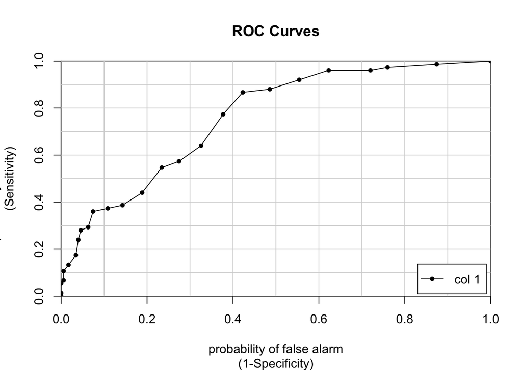

```
##              [,1]
## Good vs. Bad 0.76
```

```r
probsTest <- predict(btree, type="prob", newdata=germancredit.test)
predsBtree <- probsTest[,2]  ##save for later


##AUC onthe hold-out/Test partition
colAUC(predsBtree, germancredit.test$response, plotROC=TRUE)
```

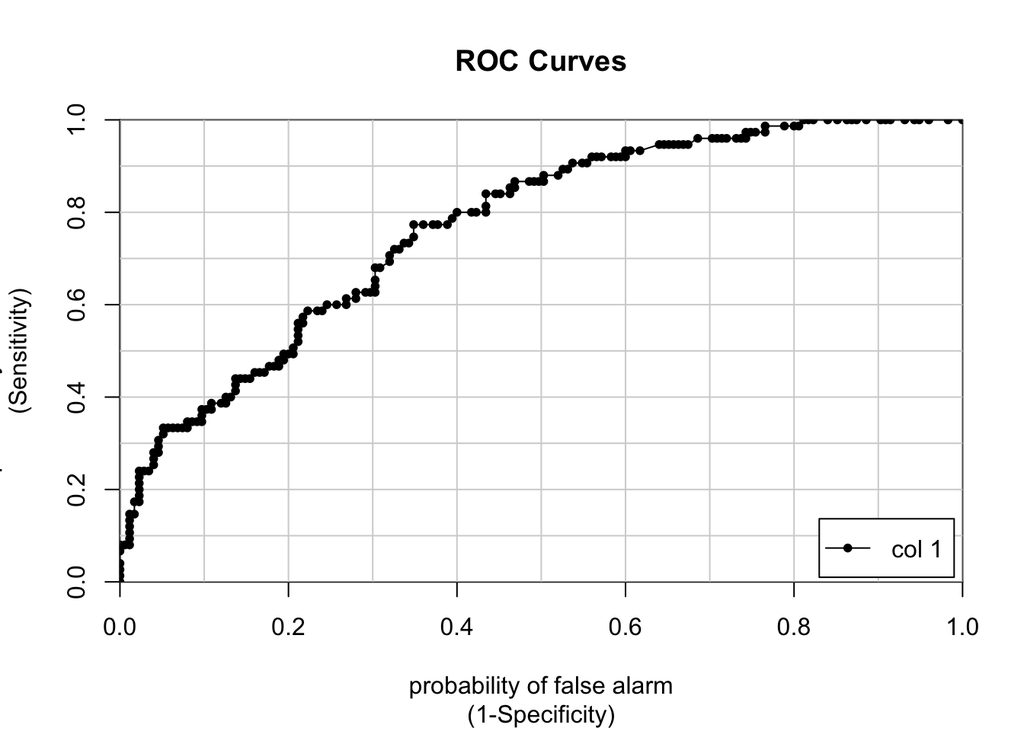

```
##                   [,1]
## Good vs. Bad 0.7688762
```

```r
###build a Random Forest Model
set.seed(1234)
RFmodel <- train(response ~., data = germancredit.train,  method = "rf", metric=cmetric,
               trControl = trainControl("cv", number = 10, summaryFunction=twoClassSummary, classProbs = TRUE)
)
probsTest <- predict(RFmodel, type="prob", newdata=germancredit.test)
predsRF <- probsTest[,2]  ##save for later

##AUC onthe hold-out/Test partition
colAUC(predsRF, germancredit.test$response, plotROC=TRUE)
```

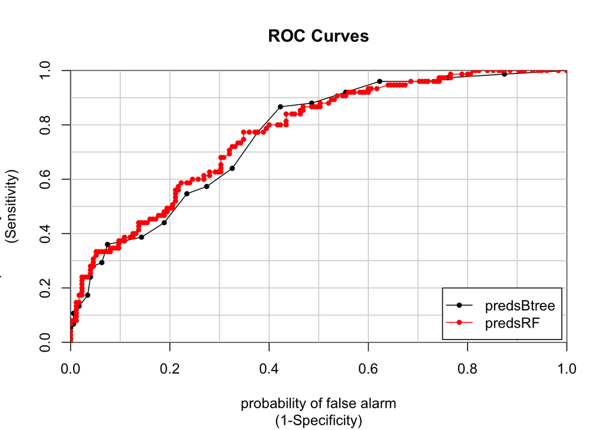

```
##              predsBtree   predsRF
## Good vs. Bad       0.76 0.7688762
```

```r
##compare the models on the hold-out/Test partition
colAUC(cbind(predsBtree, predsRF), germancredit.test$response, plotROC=TRUE)
```

The Random Forest model is more efficient in predicting the success and has a high AUC emphesizing higher sensitivity.

#### 2.Boosting–Building a “strong” model by successively training models on weighted versions of the training data, where more weight is given to examples that were misclassified by earlier rounds. Using this approach, you will build two ensemble models: (a) an Adaptive Tree Boosting Model (method=“adaboost”), and (b) an (eXtreme) Gradient Boosted Tree model (method=“xgbTree”)

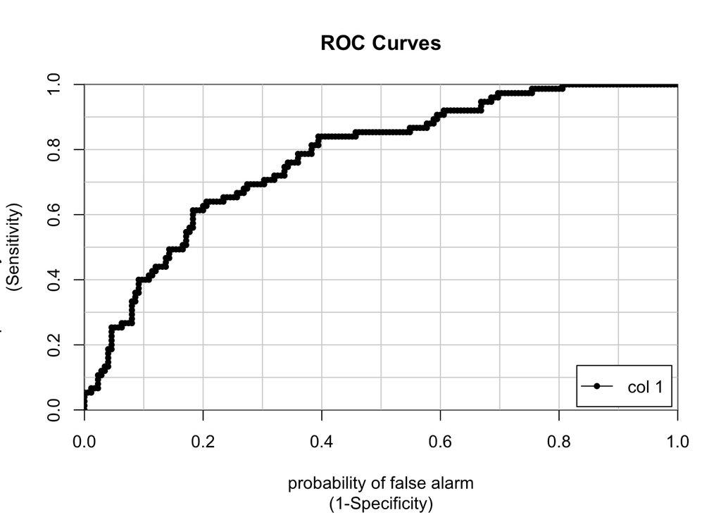

```
##                   [,1]
## Good vs. Bad 0.7741714
```

```r
set.seed(1234)
adatree <- train(response ~., data = germancredit.train, method = "adaboost", metric=cmetric,
               trControl = trainControl("cv", number = 10, summaryFunction=twoClassSummary, classProbs = TRUE)
)
probsTest <- predict(adatree, type="prob", newdata=germancredit.test)
predsAdatree <- probsTest[,2]  ##save for later

##AUC  on the hold-out/Test partition
colAUC(predsAdatree, germancredit.test$response, plotROC=TRUE)
```

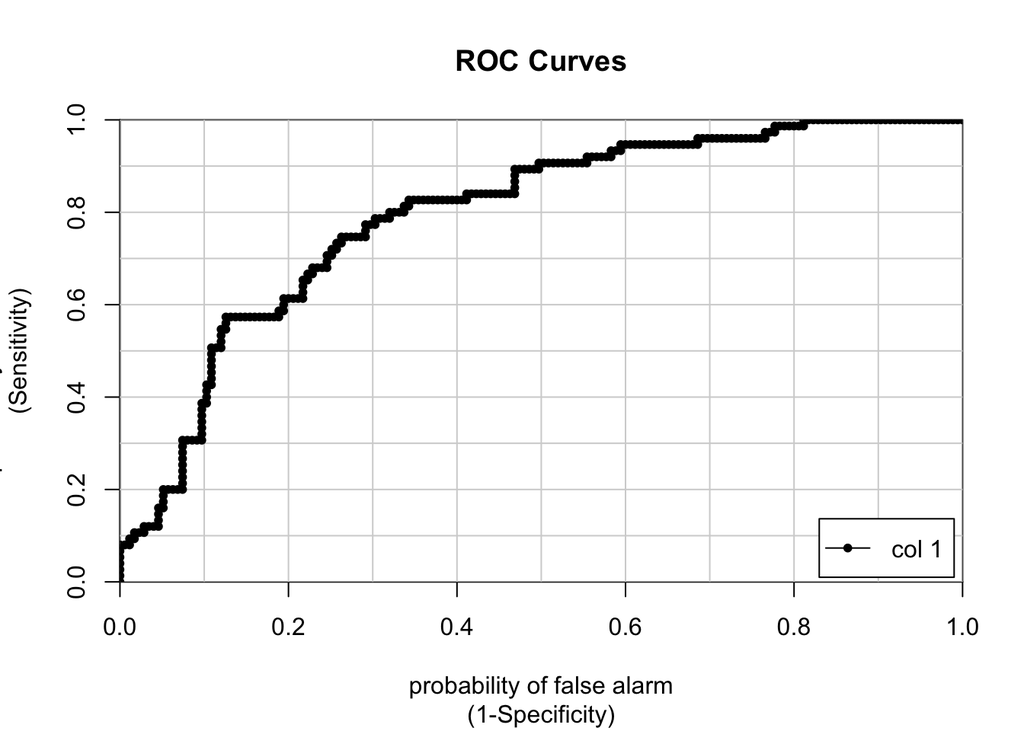

```
##                [,1]
## Good vs. Bad 0.7936
```

```r
###build a Boosted Tree Model using xgbTree
set.seed(1234)
xgbmodel <- train(response ~., data = germancredit.train, method = "xgbTree", metric=cmetric,
                 trControl = trainControl("cv", number = 10, summaryFunction=twoClassSummary, classProbs = TRUE)
)
probsTest <- predict(xgbmodel, type="prob", newdata=germancredit.test)
predsxgb <- probsTest[,2]  ##save for later


##AUC  on the hold-out/Test partition
colAUC(predsxgb, germancredit.test$response, plotROC=TRUE)
```

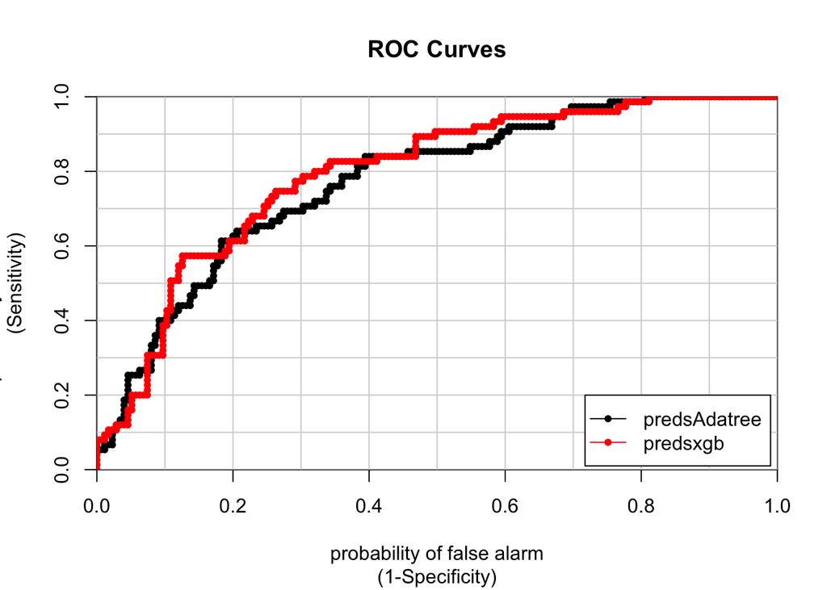

```
##              predsAdatree predsxgb
## Good vs. Bad    0.7741714   0.7936
```

```r
##compare the models on the hold-out/Test partition
colAUC(cbind(predsAdatree,  predsxgb), germancredit.test$response, plotROC=TRUE)
```

#### Gradient boot model seems to better than the ADAboost model as it has higher AUC.

#### 3. Stacking–Combining the predictions of multiple models via a meta-classifier (or meta-regressor for regression problems). The result is a two-tiered ensemble. The base level models are trained based on a complete training set, then the meta-model is trained on the outputs of the base level model as features. You can manually build a stacked ensemble model, but the CaretEnsemble package makes this task much simpler. Use the caretList function in CaretEnsemble (Links to an external site.)Links to an external site. package to rebuild and tune the four base-level models you built in assignment #3, and then using caretStack build a “glm” as the meta-model to aggregate the predictions of the four base-level models.

```r
set.seed(1234)

library(caretEnsemble)
my_control <- trainControl(method = "cv", # for “cross-validation”
                           number = 10, # number of k-folds
                           savePredictions = "final",
                           summaryFunction=twoClassSummary, classProbs = TRUE,
                           allowParallel = TRUE)

#train a list of models all at the same time REPEATS WHAT WE HAVE DONE BEFORE,
model_list <- caretList(response ~., data = germancredit.train,
                        trControl = my_control,
                        methodList = c("glm", "rpart", "nnet"),
                        metric="ROC",
                        tuneList = NULL,
                        continue_on_fail = FALSE,
                        preProcess = c("center", "scale"))
#compare the three models based on resampling
results <- resamples(model_list)
summary(results)
```

```
##
## Call:
## summary.resamples(object = results)
##
## Models: glm, rpart, nnet
## Number of resamples: 10
##
## ROC
##            Min.   1st Qu.    Median      Mean   3rd Qu.      Max. NA's
## glm   0.7268253 0.7642045 0.7904572 0.7829473 0.7957699 0.8469900    0
## rpart 0.5000000 0.6453593 0.6751138 0.6745535 0.7289833 0.7658863    0
## nnet  0.7032590 0.7257873 0.7473776 0.7500833 0.7616564 0.8185619    0
##
## Sens
##            Min.   1st Qu.    Median      Mean   3rd Qu.      Max. NA's
## glm   0.7307692 0.8349057 0.9047533 0.8781930 0.9241655 0.9423077    0
## rpart 0.8113208 0.9042997 0.9143687 0.9145864 0.9241655 1.0000000    0
## nnet  0.6538462 0.7320392 0.7523585 0.7618650 0.7724964 0.8846154    0
##
## Spec
##            Min.   1st Qu.    Median      Mean   3rd Qu.      Max. NA's
## glm   0.3636364 0.4347826 0.4446640 0.4711462 0.5000000 0.6086957    0
## rpart 0.0000000 0.1477273 0.3043478 0.2610672 0.3730237 0.4347826    0
## nnet  0.3181818 0.5909091 0.6521739 0.6205534 0.6921937 0.7826087    0
```

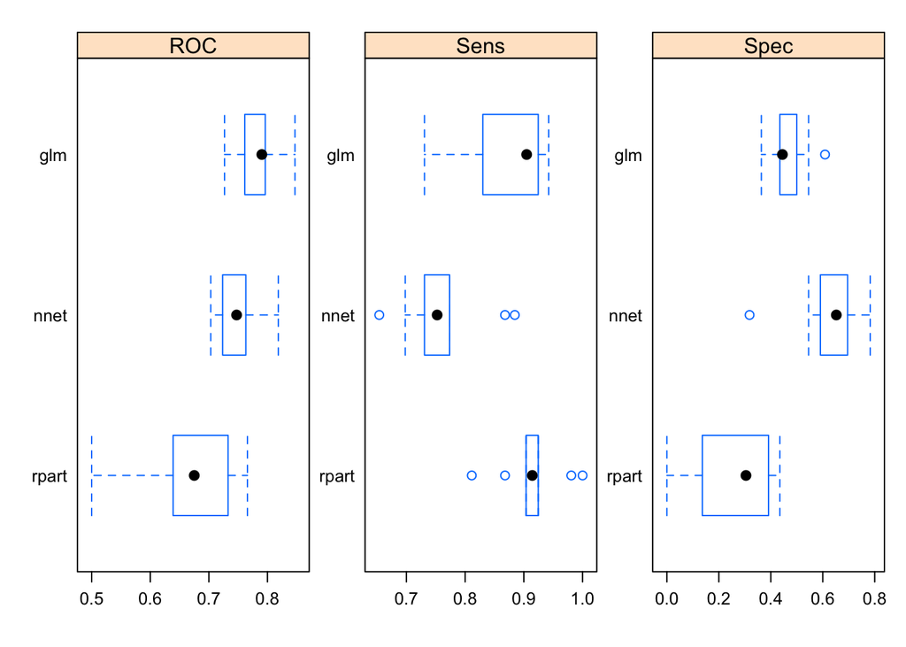

```r
##glm model seems to be best upon comparison with highest AUC.

# Box plots to compare models
scales <- list(x=list(relation="free"), y=list(relation="free"))
bwplot(results, scales=scales)
```

```r
summary(results, metric="ROC")
```

```
##
## Call:
## summary.resamples(object = results, metric = "ROC")
##
## Models: glm, rpart, nnet
## Number of resamples: 10
##
## ROC
##            Min.   1st Qu.    Median      Mean   3rd Qu.      Max. NA's
## glm   0.7268253 0.7642045 0.7904572 0.7829473 0.7957699 0.8469900    0
## rpart 0.5000000 0.6453593 0.6751138 0.6745535 0.7289833 0.7658863    0
## nnet  0.7032590 0.7257873 0.7473776 0.7500833 0.7616564 0.8185619    0
```

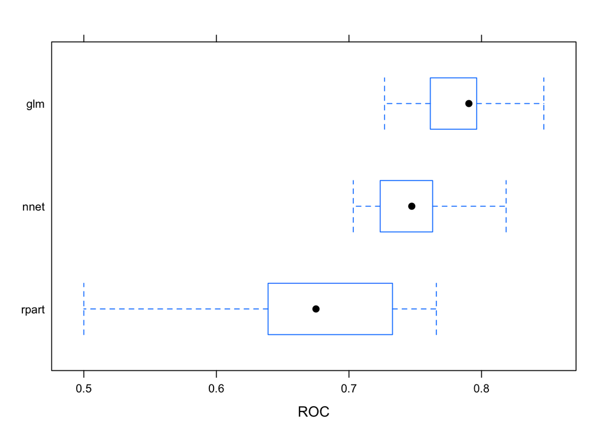

```r
bwplot(results, metric="ROC")
```

```r
modelCor(results)  #ideally,we would ensemble models that are low correlated with each other
```

```
##             glm     rpart      nnet
## glm   1.0000000 0.3821004 0.5941697
## rpart 0.3821004 1.0000000 0.1458527
## nnet  0.5941697 0.1458527 1.0000000
```